# Texto 1 - Condições de vida da população negra

Pablo Castro

19/06/2026

# 1 Introdução

A análise das condições de vida da população negra é componente central da agenda de promoção da igualdade racial no Brasil e constitui uma das prioridades do Ministério da Igualdade Racial. Essa diretriz está alinhada ao objetivo de fortalecer o monitoramento das desigualdades raciais e aprimorar a capacidade de formulação de políticas públicas baseadas em evidências. Nesse contexto, a presente consultoria tem como finalidade produzir diagnósticos desagregados por cor e raça, com base no Censo Demográfico 2022. O Censo é a principal fonte de dados do país e possibilita identificar, com abrangência territorial e elevado detalhamento sociodemográfico, padrões persistentes de desigualdade que afetam de forma sistemática a população preta e parda.

Este texto integra o conjunto de nove entregas previstas no Contrato IC nº 000199/2025-0 e corresponde ao primeiro eixo temático do Produto 2, dedicado à caracterização ampla das condições de vida da população negra no Brasil. Em conformidade com o Plano de Trabalho Geral, este texto desempenha um papel panorâmico, articulado ao calendário do Novembro Negro, reunindo indicadores essenciais sobre demografia, educação, trabalho, renda e moradia, sempre em comparação com a população não negra e com recortes por sexo e território.

Nesse sentido, apresenta-se aqui um conjunto estruturado de indicadores derivados do Censo 2022 e de bases complementares, organizados para evidenciar diferenças nos níveis de escolaridade, padrões demográficos, participação no mercado de trabalho, rendimentos, informalidade e condições de moradia. Além disso, o texto incorpora visualizações sintéticas — mapas, comparações regionais e gráficos descritivos — que facilitam a leitura dos resultados e contribuem para a compreensão das desigualdades raciais em diferentes escalas territoriais.

A análise proposta não busca esgotar a complexidade do tema, mas oferecer um panorama consistente que servirá de base para os textos subsequentes da consultoria, nos quais temas específicos — como educação, mercado de trabalho, condições de moradia e justiça climática — serão aprofundados com maior nível de detalhamento.

# 2 Estrutura demográfica da população brasileira

Nessa seção apresentamos a composição demográfica da população brasileira e sua comparação entre os Censos Demográficos de 2010 e 2022.

## 2.1 Distribuição da população por raça/cor – Brasil (2010 e 2022)

A Figura 2.1 mostra a composição racial da população brasileira por cor ou raça. Aqui e ao longo do trabalho, consideramos **população negra** como a soma de **pretos e pardos**, em consonância com a classificação utilizada pelo IBGE, e **população não negra** como o somatório das demais categorias de cor ou raça presentes na população brasileira (branca, amarela e indígena). É importante destacar que, dentro do grupo não negro, a maioria é composta por pessoas brancas, de modo que as estatísticas desse agrupamento refletem, em grande medida, a média da população branca.

Em 2022, a composição racial do Brasil era de **43,5% branca, 10,2% preta, 0,4% amarela, 45,3% parda e 0,6% indígena**, o que significa que a população negra (pretos + pardos) representa a maioria da população brasileira, com mais de 55% do total.

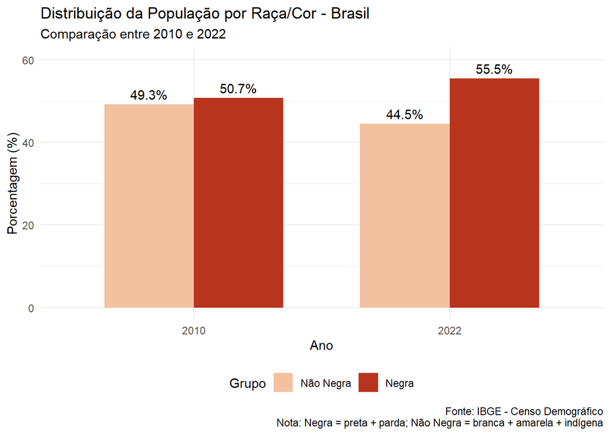

Figura 2.1: Distribuição da população por raça/cor (2010 e 2022)

A Figura 2.1 mostra que a população negra representa a maioria da população brasileira, com mais de 55% do total. Entre 2010 e 2022, a população brasileira passou de 191 milhões para 203 milhões de habitantes, um crescimento de aproximadamente 6,5%. No mesmo período, a população negra cresceu de 97 milhões para 113 milhões pessoas, um aumento em torno de 16,5%, portanto mais que proporcional ao crescimento da população total. Esse resultado indica não apenas a expansão demográfica da população negra, mas também um processo de maior autoidentificação como preta ou parda ao longo do tempo, tema amplamente discutido na literatura sobre desigualdades raciais no Brasil (Osório, 2003).

## 2.2 Distribuição territorial da população negra, preta e parda (municípios)

A Figura 2.2 apresenta a distribuição da população negra total (pretos + pardos), da população preta e da população parda por município brasileiro, com base no Censo 2022.

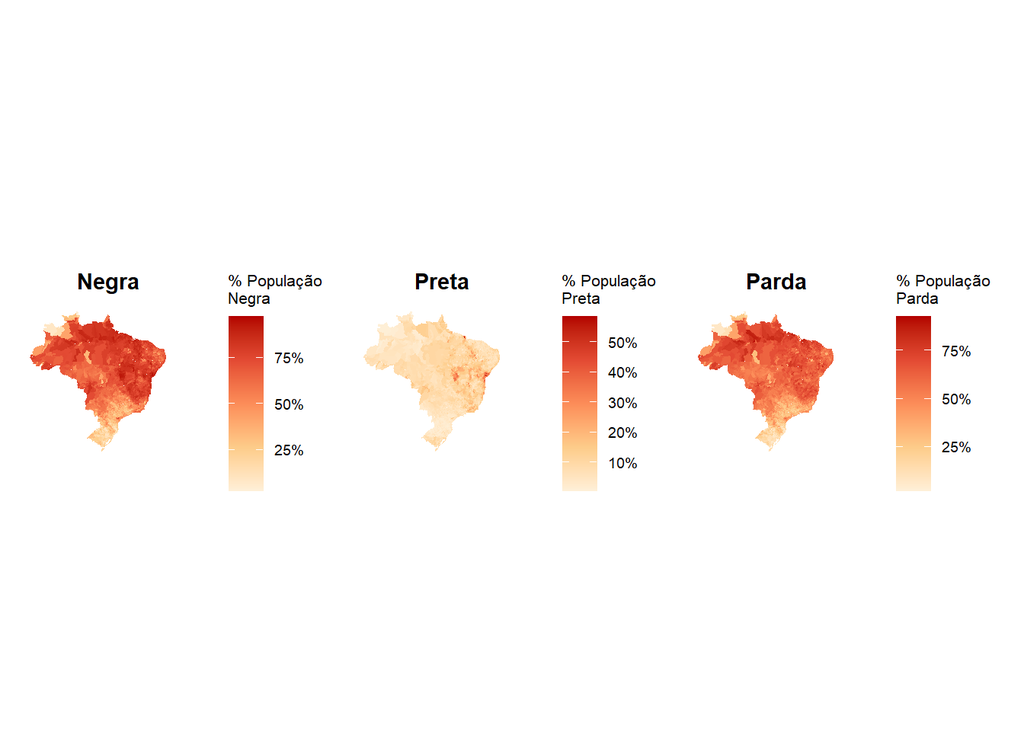

Figura 2.2: Distribuição da população negra, preta e parda por município – Brasil, Censo 2022

A Figura 2.2 apresenta a distribuição territorial da população negra, preta e parda no nível municipal, permitindo visualizar com maior precisão a heterogeneidade espacial da composição racial no país. A população negra se concentra nas regiões Norte e Nordeste, onde a proporção supera 50% em grande parte dos municípios. Essas áreas destacam-se como territórios historicamente marcados por processos de ocupação, migração interna, desigualdades estruturais e persistência de hierarquias raciais, o que contribui para a formação de padrões territoriais consistentes entre cor/raça e condições socioeconômicas (Telles, 2004).

A análise separada das populações preta e parda revela dinâmicas distintas. A população preta apresenta concentrações mais elevadas em municípios do Recôncavo Baiano, litoral sul da Bahia e algumas áreas do Norte, sinalizando territórios de forte ancestralidade africana e continuidade histórica das populações afrodescendentes. Já a população parda possui distribuição mais espalhada pelo território, predominando em grande parte do Norte, Nordeste e Centro-Oeste, refletindo padrões de miscigenação e autorreconhecimento fortemente influenciados por contextos regionais (Telles, 2004). Em conjunto, os três mapas evidenciam que a distribuição racial no Brasil é marcada por fortes desigualdades espaciais, que precisam ser consideradas para o desenho de políticas públicas territorialmente sensíveis e alinhadas ao enfrentamento das desigualdades raciais.

# 3 Educação e alfabetização

Nesta seção analisamos a taxa de alfabetização da população negra em comparação à população não negra, com base nos dados do Censo Demográfico 2022. Trabalhamos com o indicador oficial do IBGE, que mensura a proporção de pessoas alfabetizadas entre aquelas com 15 anos ou mais. Esse indicador é amplamente utilizado em diagnósticos educacionais no Brasil e internacionalmente (UNESCO, 2022), sendo um componente estrutural das desigualdades raciais historicamente discutidas pela literatura (HASENBALG, 2005).

## 3.1 Taxa de alfabetização por raça/cor e sexo

A Figura 3.1 apresenta a taxa de alfabetização da população negra e não negra, total e por sexo. Os resultados mostram uma diferença de aproximadamente **2 pontos percentuais** na taxa geral de alfabetização entre negros e não negros. No recorte por sexo, observa-se que essa desigualdade é mais acentuada entre homens — diferença próxima de **8 pontos percentuais** — enquanto entre mulheres a taxa é bastante semelhante entre os grupos raciais.

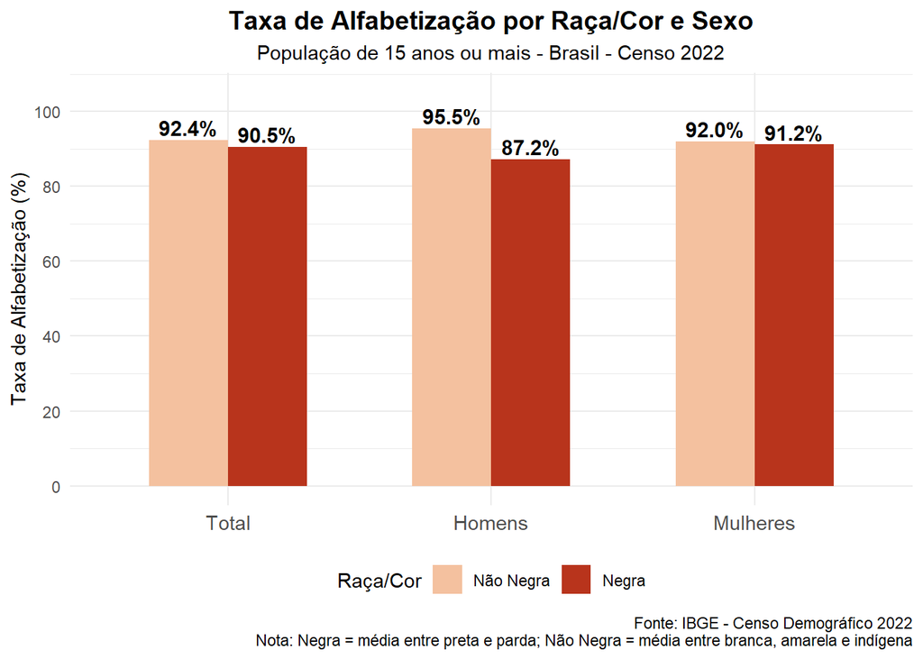

Figura 3.1: Taxa de alfabetização por raça/cor e sexo – população de 15 anos ou mais, Brasil, 2022

## 3.2 Taxa de alfabetização da população negra por município

A Figura 3.2 apresenta a taxa de alfabetização da população negra no nível municipal. A análise com maior granularidade territorial revela padrões intraestados invisíveis na escala por UF: municípios do interior do Nordeste — especialmente no Sertão do Piauí, do Maranhão e de Alagoas — concentram os menores índices do país, abaixo de 80%. Essa sobreposição entre maior proporção de população negra e menores taxas de alfabetização evidencia como desigualdades raciais e regionais se reforçam mutuamente, configurando um padrão de vulnerabilidade educacional territorializado (IPEA, 2024).

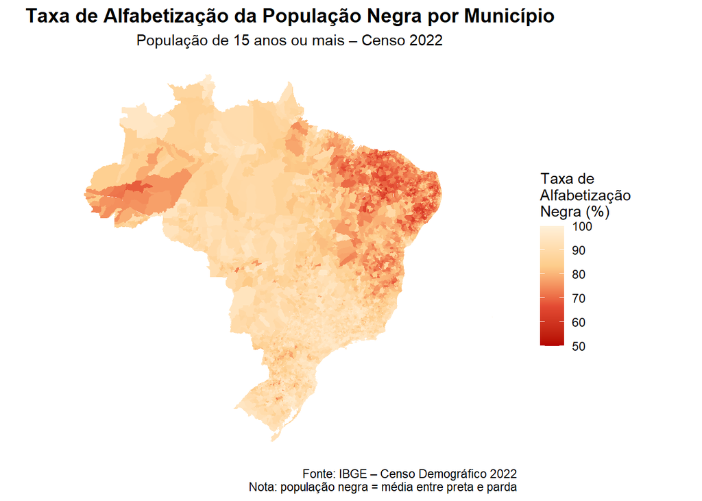

Figura 3.2: Taxa de alfabetização da população negra por município – Brasil, Censo 2022

A análise municipal permite identificar com precisão os territórios prioritários para intervenção, subsidiando o planejamento de políticas de alfabetização e escolarização com recorte racial e territorial.

## 3.3 Taxa de alfabetização por raça/cor e faixa etária

A Figura 3.3 apresenta a taxa de alfabetização por faixa etária. Observamos um padrão geracional, as desigualdades raciais são maiores entre as gerações mais velhas e diminuem progressivamente, até desaparecerem entre os mais jovens.

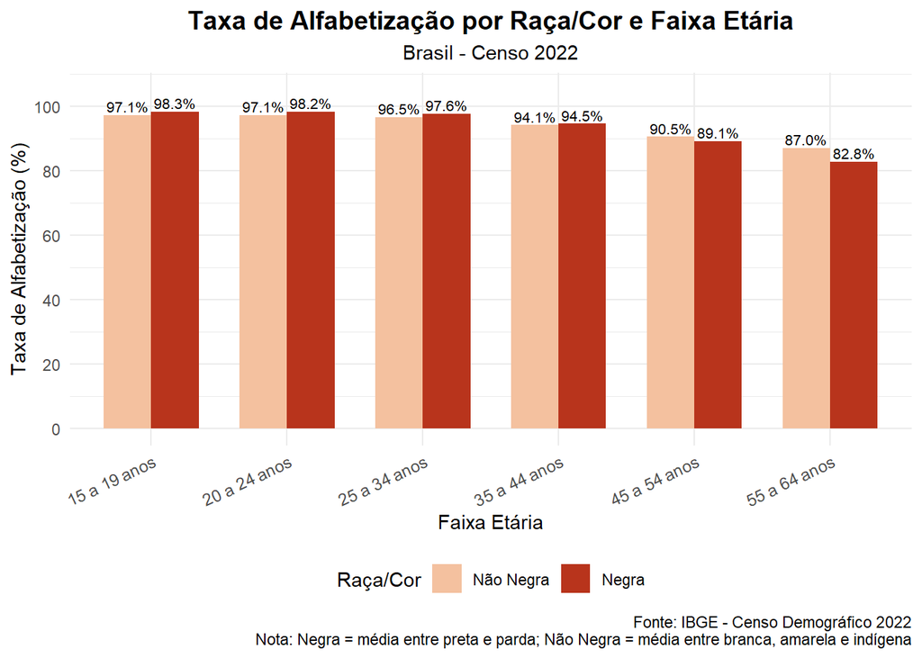

Figura 3.3: Taxa de alfabetização por raça ou cor e faixa etária (2022)

Esse movimento é consistente com o processo de expansão educacional brasileiro das últimas décadas e indica avanços importantes na universalização da alfabetização, sobretudo entre jovens negros. No entanto, como discutiremos nas próximas seções, a redução desigualdades no alfabetismo não elimina os impactos de desigualdades acumuladas historicamente, que continuam se refletindo em diferenças de escolaridade, acesso ao ensino superior, ocupações no mercado de trabalho e rendimentos.

# 4 Mercado de trabalho e renda

Esta seção apresenta evidências sobre trabalho e rendimento da população negra em comparação à população não negra, com base nos microdados da PNAD Contínua de 2025 e nos dados do Censo Demográfico 2022. As análises com dados da PNAD-C permitem uma leitura atualizada sobre renda e formalidade; já as análises com o Censo agregam maior desagregação territorial — incluindo o nível municipal — e cobrem a totalidade da população ocupada.

## 4.1 Rendimento médio por hora por nível educacional e raça/cor

A Figura 4.1 mostra o rendimento médio por hora trabalhada segundo nível educacional e raça/cor. No total da população ocupada, o rendimento médio por hora dos não negros é de aproximadamente **R$ 23,72**, enquanto entre os negros é de cerca de **R$ 14,71**. Isso implica que, em média, pessoas negras recebem em torno de **38%** a menos por hora trabalhada do que pessoas não negras, mesmo considerando apenas indivíduos ocupados.

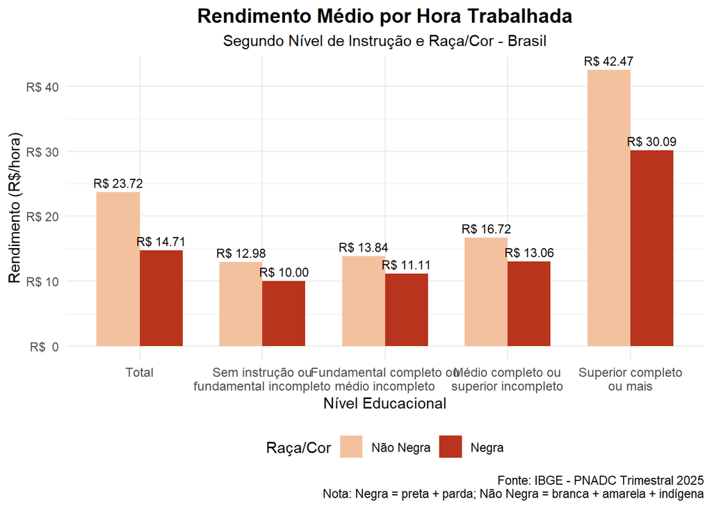

Figura 4.1: Rendimento médio por hora trabalhada, por nível educacional e raça/cor – Brasil, PNADC 2025

Esse diferencial está associado, em parte, a desigualdades educacionais acumuladas ao longo da trajetória escolar, como documentam estudos sobre desigualdade educacional por raça no Brasil (Laudares, 2023). No entanto, o própria Figura 4.1 evidencia que **a educação, por si só, não elimina o diferencial racial**. Em todos os níveis de instrução, o rendimento médio de negros permanece abaixo do observado entre não negros, e o hiato se torna maior à medida que se analisam trabalhadores com mais anos de estudo: negros com nível superior ganham, em média, cerca de **R$ 30,09** por hora, enquanto não negros recebem aproximadamente **R$ 42,47**, o que corresponde a uma diferença próxima de **29%**.

Esse padrão é consistente com a literatura que aponta o papel de mecanismos de discriminação, segmentação ocupacional, barreiras de acesso a posições de maior prestígio e retornos diferenciados ao capital humano de negros e não negros (Arcand e D’Hombres, 2004). Estudos recentes também destacam que políticas como o salário mínimo têm contribuído para reduzir desigualdades raciais de salario na base da distribuição, ao elevar rendas de trabalhadores em ocupações de baixa remuneração, ainda que sem eliminar os diferenciais em faixas mais altas da distribuição salarial (Derenoncourt et al., 2021).

## 4.2 Informalidade por raça/cor

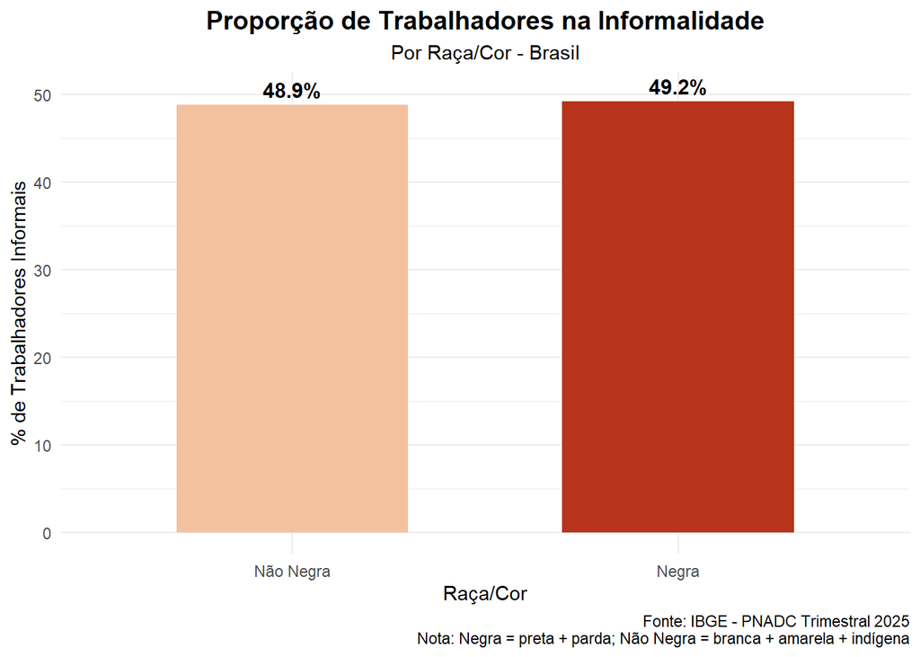

Figura 4.2: Proporção de Trabalhadores na Informalidade, Brasil, PNADC 2025

Porém, como mostra a Figura 4.3, a maioria absoluta dos trabalhadores informais é negra. Isso ocorre porque negros representam uma parcela maior da força de trabalho total, e portanto mesmo com taxas semelhantes, o volume de trabalhadores informais negros é maior.

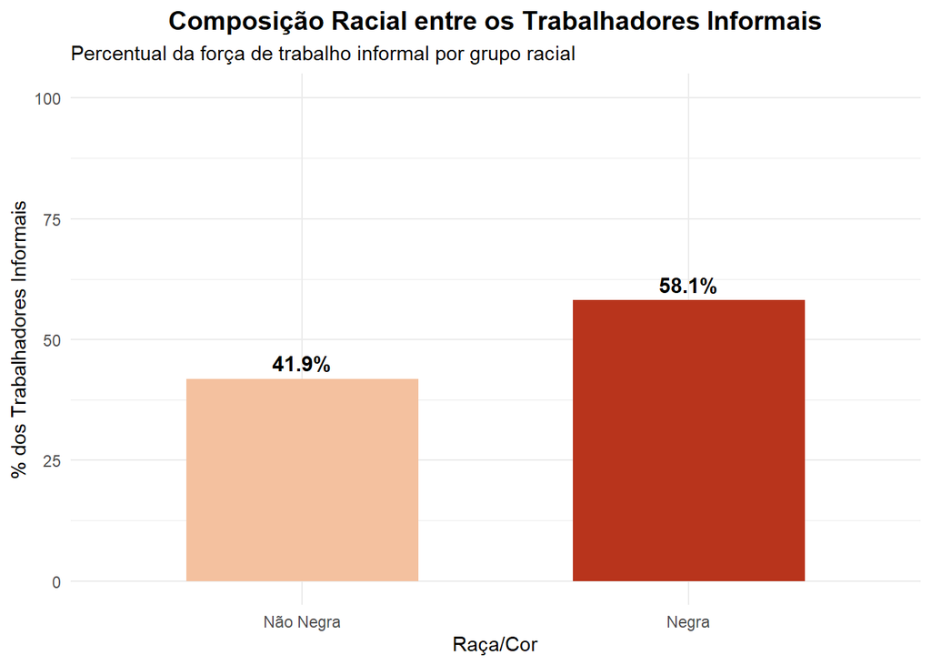

Figura 4.3: Composição racial dos trabalhadores informais, Brasil, PNADC 2025

## 4.3 Rendimento médio formal e informal por raça/cor

A Figura 4.4 compara o rendimento médio habitual entre trabalhadores formais e informais, segundo raça/cor. Entre os trabalhadores formais, a renda média de não negros é de aproximadamente R$ 4.095, enquanto a de trabalhadores negros é de R$ 2.785. Isso significa que, mesmo dentro do segmento formal — que tende a ter salários mais altos e maior proteção — trabalhadores negros recebem cerca de 32% menos do que trabalhadores não negros.

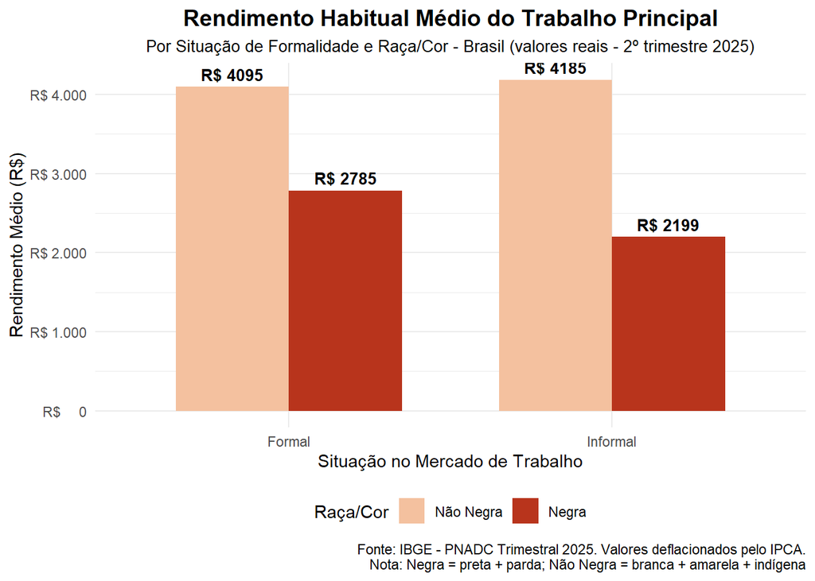

Figura 4.4: Rendimento habitual médio do trabalho principal por formalidade e raça/cor – Brasil, PNADC 2025

Essa evidência reforça que a desigualdade racial no mercado de trabalho não se explica apenas pela maior presença de negros na informalidade. Mesmo dentro de cada segmento — formal e informal — trabalhadores negros recebem sistematicamente menos do que trabalhadores não negros, indicando diferenças salariais persistentes independentemente do tipo de vínculo.

## 4.4 Taxa de desocupação por nível de instrução – Censo 2022

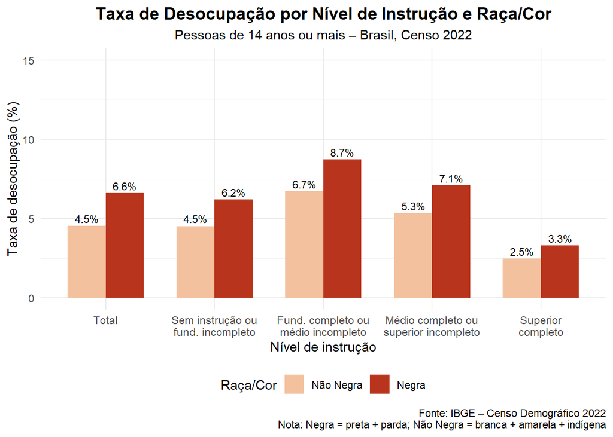

Figura 4.5: Taxa de desocupação por nível de instrução e raça/cor – Brasil, Censo 2022

## 4.5 Rendimento médio por nível de instrução – Censo 2022

A Figura 4.6 apresenta o rendimento nominal médio mensal por nível de instrução e raça/cor, segundo o Censo 2022. Os dados mostram que em todos os níveis educacionais o rendimento médio da população negra é inferior ao da população não negra, e que essa diferença se aprofunda com o aumento da escolaridade — padrão que reforça a existência de discriminação salarial racial para além das diferenças de capital humano.

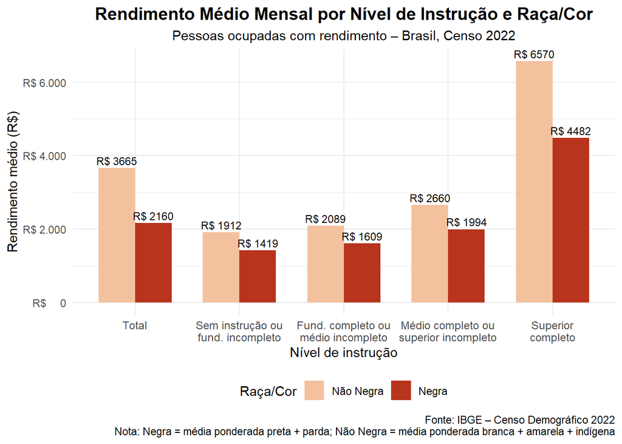

Figura 4.6: Rendimento médio mensal por nível de instrução e raça/cor – Brasil, Censo 2022

## 4.6 Taxa de desocupação da população negra por município – Censo 2022

A Figura 4.7 apresenta a taxa de desocupação da população negra (pretos e pardos) no nível municipal. A distribuição espacial revela uma forte concentração de maiores taxas no Nordeste e em partes do Norte, regiões em que estruturas produtivas menos diversificadas combinam-se com menor oferta de empregos formais. Municípios do interior baiano, piauiense e maranhense apresentam as taxas mais elevadas, ao mesmo tempo em que concentram grandes proporções de população negra — evidenciando uma sobreposição territorial entre vulnerabilidade racial e desocupação.

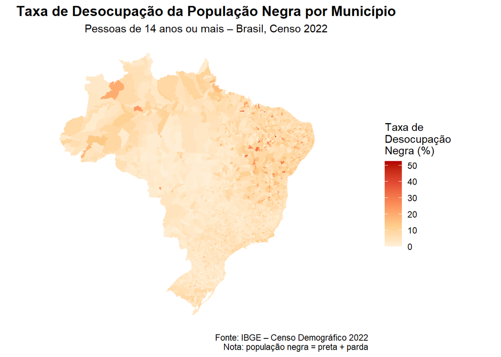

Figura 4.7: Taxa de desocupação da população negra por município – Brasil, Censo 2022

## 4.7 Rendimento médio da população negra por município – Censo 2022

A Figura 4.8 mostra o rendimento nominal médio mensal da população negra por município. A heterogeneidade territorial é expressiva: municípios do interior do Nordeste e do Norte registram rendimentos médios abaixo de R$ 1.500, enquanto capitais e municípios do Centro-Sul apresentam médias superiores a R$ 2.500. Essa análise municipal permite identificar as regiões onde o hiato racial de renda se combina com baixos patamares absolutos de rendimento, sinalizando prioridades para políticas de transferência de renda e geração de emprego com recorte racial.

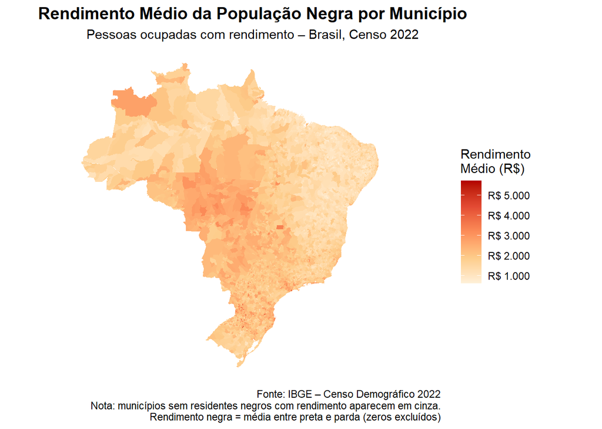

Figura 4.8: Rendimento médio mensal da população negra por município – Brasil, Censo 2022

# 5 Estrutura etária e envelhecimento

## 5.1 Índice médio de envelhecimento por raça/cor

A análise da estrutura etária mostra diferenças importantes no processo de envelhecimento entre população negra e não negra. Utilizamos o *índice de envelhecimento*, definido como:

$$\text{Índice de envelhecimento} =
\frac{\text{população de 60 anos ou mais}}{\text{população de 0 a 14 anos}} \times 100$$

Esse indicador foi calculado para cada município brasileiro, com base no Censo Demográfico de 2010 e 2022, e depois foi feita a média municipal para cada grupo racial.

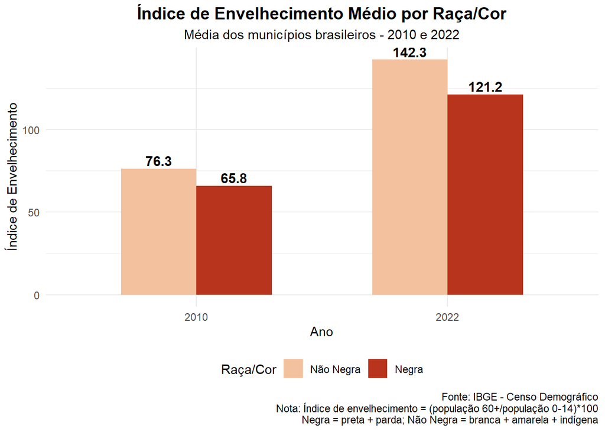

Figura 5.1: Índice médio de envelhecimento por raça/cor (2010 e 2022)

A Figura 5.1 mostra que, em ambos os anos, a população não negra apresenta índice de envelhecimento mais alto. Em 2010, a média municipal da população não negra era de 76,3, contra 65,8 entre negros. Em 2022, essa diferença aumentou: 142,3 para não negros e 121,2 para negros.

Ou seja, a população negra envelhece menos. Isso reflete uma combinação de:

- menor proporção de idosos negros,
- maior proporção de pessoas negras na infância e juventude,
- e efeitos acumulados de desigualdades sociais que reduzem a sobrevivência da população negra até idades avançadas.

## 5.2 Diferença no índice de envelhecimento entre negros e não negros por UF

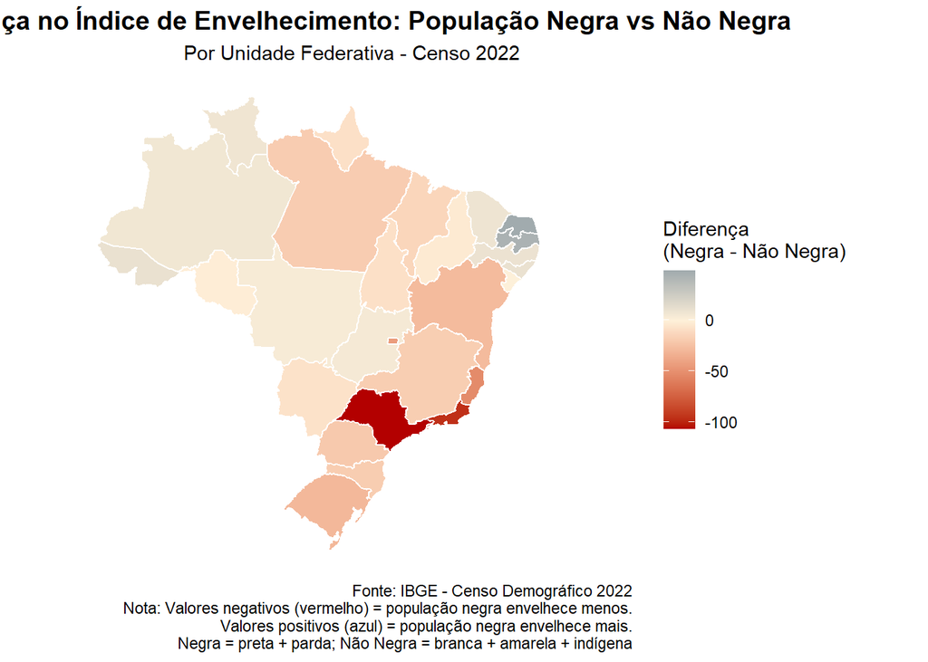

Figura 5.2: Diferença no índice de envelhecimento entre negros e não negros por UF (2022)

# 6 Condições de moradia e saneamento

Nesta seção, examinamos condições de moradia e saneamento básico, variáveis fortemente associadas à saúde e longevidade. Essas condições ajudam a explicar por que a população negra envelhece menos: piores condições habitacionais resultam em maior vulnerabilidade ambiental, sanitária e epidemiológica ao longo do ciclo de vida.

## 6.1 Composição racial por tipo de moradia

Para construir a Figura 6.1, classificamos os domicílios em: - Moradia adequada: casa, casa de vila e apartamento - Moradia precária: cortiços, habitações degradadas, malocas e estruturas improvisadas

Para cada grupo racial, somamos o total de pessoas residindo nesses tipos de moradia e calculamos o percentual dentro de cada categoria.

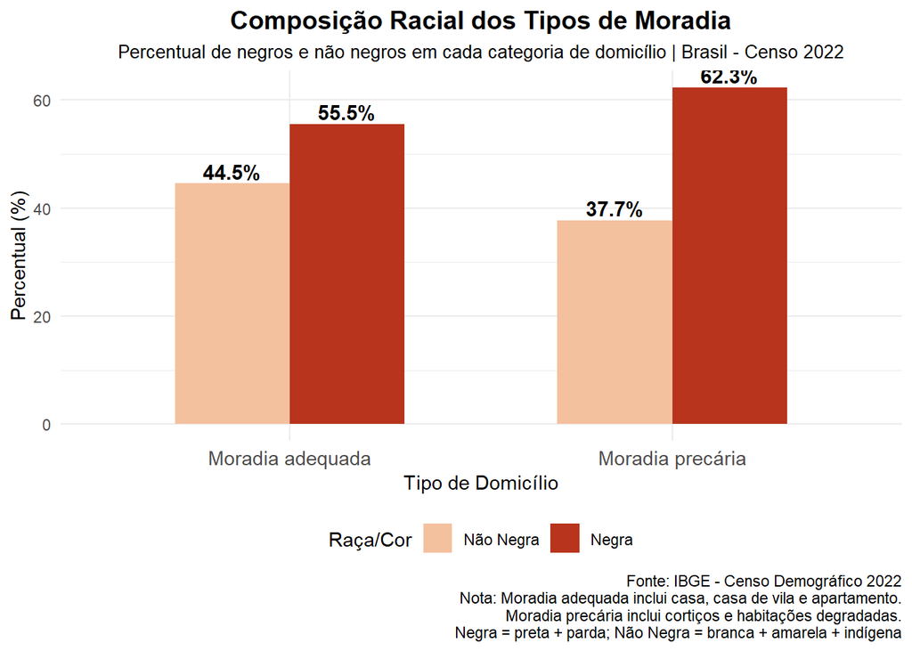

Figura 6.1: Composição racial por tipo de moradia (Censo 2022)

O resultado mostra que entre as moradias adequadas, 55,5% dos residentes são negros — proporção próxima à participação da população negra no total da população brasileira (cerca de 55%). Já entre as moradias precárias, essa participação sobe para 62,3%, indicando uma sobrerrepresentação da população negra em condições habitacionais piores. Ou seja, embora negros sejam maioria em termos absolutos, sua concentração em habitações precárias é desproporcionalmente maior do que sua participação na população total, revelando desvantagem estrutural nas condições de moradia.

## 6.2 Composição racial do acesso ao esgotamento sanitário

Para a Figura 6.2, o acesso ao esgotamento sanitário foi classificado em: - Adequado: rede geral/pluvial ou fossa séptica ligada à rede - Inadequado: fossa rudimentar, vala, rio/lago, outras formas e domicílios sem banheiro

O resultado indica que entre quem vive com saneamento adequado, negros representam 50,1% dos residentes — abaixo de sua participação na população total. Já entre quem vive em condições inadequadas, essa participação sobe para 62,7%. Assim como na moradia, negros estão mais expostos a condições sanitárias que prejudicam a saúde, aumentando riscos cumulativos e diminuindo a probabilidade de alcançar idades mais avançadas.

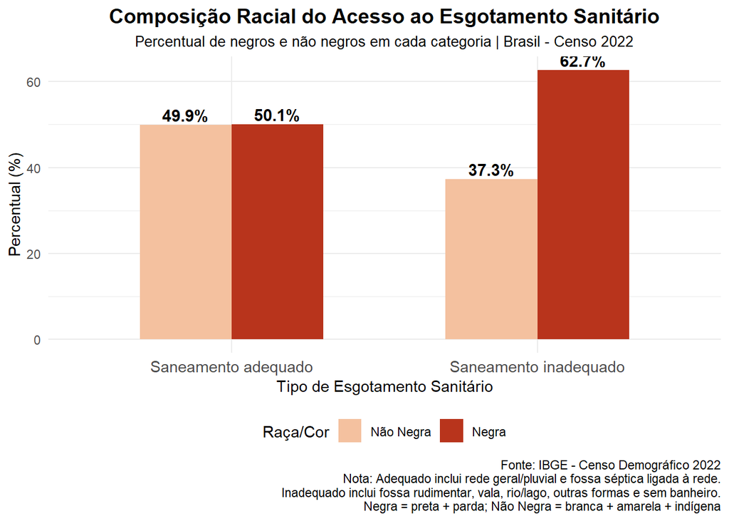

Figura 6.2: Composição racial do acesso ao esgotamento sanitário (Censo 2022)

A população negra envelhece menos porque enfrenta piores condições de vida ao longo de todo o ciclo, especialmente no que se refere à moradia e ao saneamento. Essas diferenças estruturais se reproduzem de forma consistente em todo o território nacional e ajudam a explicar uma parcela importante do diferencial de envelhecimento entre negros e não negros.

# 7 Governança municipal para igualdade racial – MUNIC 2024

A Pesquisa de Informações Básicas Municipais (MUNIC) 2024 do IBGE permite identificar quais municípios brasileiros possuem estruturas institucionais voltadas à promoção da igualdade racial. A Figura 7.1 colore os municípios que dispõem de pelo menos uma das seguintes estruturas: Órgão Gestor exclusivo ou setorial, Grupo de Trabalho Intersetorial, Legislação municipal específica, Plano Municipal de Igualdade Racial, Conselho Municipal de Igualdade Racial, Fundo Municipal de Igualdade Racial ou Política/Programa municipal voltado ao tema.

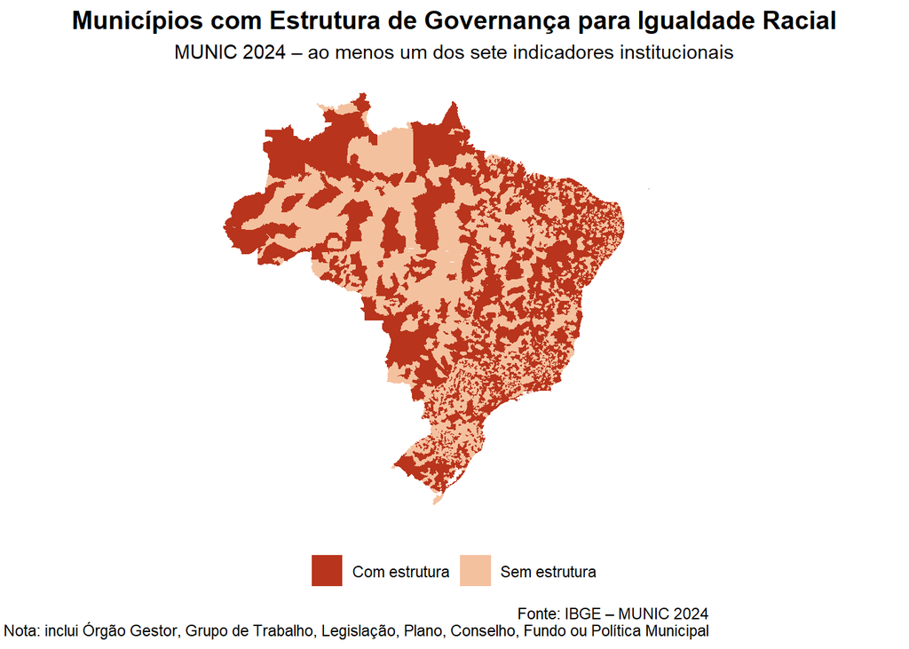

Figura 7.1: Municípios com ao menos uma estrutura de governança para igualdade racial – MUNIC 2024

# 8 Considerações finais

Os resultados apresentados neste texto mostram que as desigualdades raciais no Brasil permanecem estruturantes e se expressam de forma consistente em diferentes dimensões: rendimento, inserção ocupacional, condições de moradia, saneamento e estrutura etária. A população negra enfrenta um padrão de desvantagens ao longo do ciclo de vida, que se inicia na alfabetização — com maiores déficits em municípios do interior do Nordeste —, aprofunda-se no mercado de trabalho — onde a desocupação e os menores rendimentos persistem mesmo para negros com ensino superior — e se consolida nas condições habitacionais e sanitárias, com sobrerrepresentação da população negra em moradias precárias e sem saneamento adequado.

Nesse sentido, recomenda-se ao Ministério da Igualdade Racial: (i) priorizar a expansão do SINAPIR — Sistema Nacional de Promoção da Igualdade Racial — nos municípios do interior do Nordeste e do Norte que combinam alta proporção de população negra com ausência de estruturas institucionais; (ii) utilizar os indicadores municipais aqui produzidos — taxa de desocupação negra, rendimento médio e taxa de alfabetização — como critérios territoriais para priorização de programas de transferência de renda, qualificação profissional e políticas habitacionais; e (iii) fortalecer o monitoramento contínuo dessas desigualdades a partir das edições futuras do Censo e da MUNIC, garantindo a atualização dos diagnósticos como base para a avaliação das políticas implementadas.

# 9 Referências Bibliográficas

ARCAND, Jean-Louis; D’HOMBRES, Béatrice. *Racial Wage Differentials in Brazil: A Distributional Analysis*. Washington, DC: The World Bank, 2004. (World Bank Policy Research Working Paper, n. 2971).

DERENONCOURT, Ellora; GÉRARD, François; LAGOS, Lorenzo; MONTIALOUX, Claire. *Racial Inequality, Minimum Wage Spillovers, and the Informal Sector*. Unpublished manuscript, 15 maio 2021.

HASENBALG, Carlos. *Discriminação e desigualdades raciais no Brasil*. Belo Horizonte: UFMG, 2005.

IPEA. *Retrato das desigualdades de gênero e raça*. Brasília: IPEA, 2024.

OSÓRIO, Rafael Guerreiro. *O sistema classificatório de cor ou raça do IBGE*. Brasília: IPEA, 2003.

TELLES, Edward E. *Race in Another America: The Significance of Skin Color in Brazil*. Princeton: Princeton University Press, 2004. DOI: https://doi.org/10.2307/j.ctt6wpzpb.

UNESCO. *Global Education Monitoring Report*. Paris: UNESCO, 2022.